# Reporte EJECUTIVO

Fernando Chávez 142353, Bernardo Mondragón 143743, Rayan García 144424

17 de octubre de 2016

## 1. Introducción

El Proyecto consiste en el análisis de la incidencia en mordeduras de perro en México del año 2004 a 2015. Dicha incidencia se ordena por Fuente de Notificación, Mes de Ocurrencia y Grupo de Edad. Los datos usados en este proyecto provienen de la secretaría de salud: http://www.epidemiologia.salud.gob.mx/anuario/html/anuarios.html.

El objetivo es presentar una serie de gráficas y análisis de cómo ha cambiado la incidencia de las mordeduras de perro a través de los años. Los datos obtenidos de las distintas clasificaciones (i.e fuente de notificación, mes de ocurrencia y grupo de edad) se presentan de manera clara y organizada.

Creemos que el análisis de datos es importante para el sector salud, ya que podría utilizarse para conocer la tendencia, la frecuencia y la variabilidad de los datos. Ya que si el sector salud conoce de manera detallada la incidencia de las mordeduras de perro en México puede tomar mejores decisiones para atender a la población, se pueden crear campañas o se pueden tomar con mayor seriedad los estados “problemáticos”.

## 2. Definición del Problema

En la obtención de los datos surgen varias preguntas a resolver y aclarar: ¿Cuál es la tendencia de las mordeduras de perro a través de los años?, ¿Cómo se cambió la incidencia de las mordeduras de perro en los estados cada año?, ¿Cómo se fueron reportando las mordeduras de perro en las fuentes de notificación a través de los años?, ¿Cómo se reportaron las mordeduras en los grupos de edad a través de los años?, ¿Cuáles son los estados que están por arriba de la media en cada año?, ¿Cuáles son los máximos y mínimos a través de los años?, ¿Cómo es la tendencia de cada estado en cada año?

Para poder resolver nuestras preguntas tuvimos que plantear nuestro análisis en cuatro divisiones: La primera sería conocer el máximo, el mínimo, la media, la varianza, la desviación estándar, y los cuartiles, esto es para conocer mejor la probabilidad y la organización de nuestros datos en el tiempo.

La segunda pregunta surge de un pensamiento racional y clásico: ¿Cómo se están comportando las mordeduras en México a través de los años? es decir la tendencia.

La tercera, sería analizar cada una de nuestras variables(Fuente de Notificación, Mes de Ocurrencia y Grupo de Edad) incluyendo también por cada uno de nuestros estados el cambio en el tiempo en una multigráfica para ver con mayor precisión como los años cambian las mordeduras en el tiempo.

La cuarta, sería analizar nuestro proyecto con Boxplots, esto es para poder comparar junto con el primer análisis más detallado y ver cómo se comporta en términos de probabilidad nuestros datos y poder hacer una comparación objetiva.

## 3. Obtención y Descripción de los Datos

Se descargó cada PDF de la información de las mordeduras de perro y se convirtieron a formato Excel para más adelante poderlos pasar a formato CSV para poder hacer nuestros análisis en Rstudio. Es importante mencionar que se limpiaron los datos, se organizaron y se modificaron para que de tal manera quedaran presentables.

## 4. Calidad de los Datos

En cuanto a la calidad de los datos, se hicieron pruebas de consistencia. Es decir, se verificó que el total de los archivos de GENERAL fueran iguales los totales de HOMBRES más MUJERES. Se comprobó que no hubiera ninguna inconsistencia en la igualdad de ningún año. También se comprobó que los totales fueran correctos en cada Formato, Fuente de Notificación, Mes de Ocurrencia y Grupo de Edad.

## 5. Transformación de los Datos

Consideramos prescindible para entender el proyecto explicar cómo se encuentran los datos: Están organizados en tres tablas cada una por su respectiva fuente: Fuente de Notificación, Mes de Ocurrencia y Grupo de Edad. En cada tabla se encuentran columnas indicando: Estado, Año, Sexo(General, Hombres o Mujeres), Fuente(Fuente de Notificación, Mes de Ocurrencia o Grupo de Edad) y Total de Mordeduras.

Ejemplo:

### 5.1 Para Fuente de Noficación:

```
##                             ESTADO    SEXO ANIO FUENTE MORDEDURAS
## General.2004.1      Aguascalientes GENERAL 2004  SALUD        538
## General.2004.2     Baja California GENERAL 2004  SALUD        998
## General.2004.3 Baja California Sur GENERAL 2004  SALUD        498
## General.2004.4            Campeche GENERAL 2004  SALUD        784
## General.2004.5            Coahuila GENERAL 2004  SALUD        884
## General.2004.6              Colima GENERAL 2004  SALUD        455
```

### 5.2 Para Mes de Ocurrencia:

```
##                             ESTADO    SEXO ANIO MES MORDEDURAS
## General.2004.1      Aguascalientes GENERAL 2004 ENE         29
## General.2004.2     Baja California GENERAL 2004 ENE         99
## General.2004.3 Baja California Sur GENERAL 2004 ENE         37
## General.2004.4            Campeche GENERAL 2004 ENE         56
## General.2004.5            Coahuila GENERAL 2004 ENE         96
## General.2004.6              Colima GENERAL 2004 ENE         42
```

### 5.3 Para Grupo de Edad:

```
##                             ESTADO    SEXO ANIO        EDAD MORDEDURAS
## General.2004.1      Aguascalientes GENERAL 2004 MAYOR.A.UNO          3
## General.2004.2     Baja California GENERAL 2004 MAYOR.A.UNO         14
## General.2004.3 Baja California Sur GENERAL 2004 MAYOR.A.UNO          1
## General.2004.4            Campeche GENERAL 2004 MAYOR.A.UNO          1
## General.2004.5            Coahuila GENERAL 2004 MAYOR.A.UNO          8
## General.2004.6              Colima GENERAL 2004 MAYOR.A.UNO          3
```

## 6. Análisis Exploratorio

### 6.1 Tablas con información básica

Para cada tabla se incluye el Año, La fuente con el valor máximo y su respectivo valor, la fuente con el valor mínimo y su respectivo valor, la media, la desviación estándar, y cada cuartil.

#### 6.1.1 Información De Estados

```
##    ANIO ESTADO .MAX   MAX          ESTADO .MIN MIN    MEDIA      VAR
## 1  2004      Mexico 19556               Colima 624 4267.594 21863042
## 2  2005      Mexico 18450  Baja California Sur 654 4160.375 19400789
## 3  2006      Mexico 18972               Colima 506 4175.250 18029916
## 4  2007      Mexico 15852               Colima 442 3651.000 12905316
## 5  2008      Mexico 15555               Colima 517 3582.156 11754214
## 6  2009      Mexico 13660               Colima 471 3310.656  9242410
## 7  2010      Mexico 13538  Baja California Sur 551 3228.375  8333144
## 8  2011      Mexico 14387               Colima 666 3440.438  9502038
## 9  2012      Mexico 16686               Colima 686 3694.094 11718212
## 10 2013      Mexico 16303               Colima 571 3280.125 11043588
## 11 2014      Mexico 16972  Baja California Sur 787 3689.156 13093135
## 12 2015      Mexico 15874  Baja California Sur 597 3485.281 11819072
##         STD 1st.Q   2nd.Q  3rd.Q   4rd.Q
## 1  4675.793   624 1648.00 2646.0 4470.50
## 2  4404.633   654 1704.25 2839.5 4572.75
## 3  4246.165   506 1586.50 3028.0 4747.50
## 4  3592.397   442 1400.50 2529.5 4164.50
## 5  3428.442   517 1288.75 2250.0 4212.25
## 6  3040.133   471 1149.25 2275.5 4092.75
## 7  2886.718   551 1155.00 2440.0 3789.75
## 8  3082.538   666 1253.00 2575.0 4295.00
## 9  3423.187   686 1342.00 2705.5 4542.75
## 10 3323.189   571 1258.25 2184.0 3924.25
## 11 3618.444   787 1513.50 2591.0 4425.75
## 12 3437.888   597 1604.25 2604.5 3941.00
```

Para la información de estados pudimos notar que en todos los años el máximo fue el Estado de México, y el mínimo fue entre Colima y Baja California Sur. La media fue oscilando entre 4300 y 3200 con uns desviación estandar muy grande esto se debe a los valores atípicos tan grandes que tenemos. Pero en promedio estaían mordiendo los perros como entre 4000 y 3000 personas.

#### 6.1.2 Información De Fuente de Notificación

```
##    ANIO FUENTE .MAX    MAX FUENTE .MIN MIN    MEDIA        VAR      STD
## 1  2004       SALUD 103044       SEMAR 155 15173.67 1108885098 33299.93
## 2  2005       SALUD 100693       SEMAR 122 14792.44 1058232521 32530.49
## 3  2006       SALUD  99492       SEMAR  88 14845.33 1032919592 32139.07
## 4  2007       SALUD  87374       SEMAR 106 12981.33  795576233 28205.96
## 5  2008       SALUD  84250       SEMAR 108 12736.56  738288154 27171.46
## 6  2009       SALUD  75897       SEMAR 136 11771.22  597660410 24447.09
## 7  2010       SALUD  71902       SEMAR 171 11478.67  533861490 23105.44
## 8  2011       SALUD  74352       SEMAR 156 12232.67  570720272 23889.75
## 9  2012       SALUD  79985       SEMAR 122 13134.56  661344049 25716.61
## 10 2013       SALUD  78100       SEMAR 127 11662.67  632253830 25144.66
## 11 2014       SALUD  78830       SEMAR 163 13117.00  645352584 25403.79
## 12 2015       SALUD  73169       SEMAR 156 12392.11  558444104 23631.42
##    1st.Q 2nd.Q 3rd.Q 4rd.Q
## 1    155   431  3192  8843
## 2    122   337  3073  9659
## 3     88   392  2961 10743
## 4    106   315  2653  9285
## 5    108   352  2949  8670
## 6    136   255  2616  9121
## 7    171   318  3021  8944
## 8    156   463  2987 10066
## 9    122   464  2985 11061
## 10   127   414  3427  6271
## 11   163   445  3779  8988
## 12   156   525  3410  7696
```

En Fuente de Notificación pudimos apreciar que la Secretaría de salud siempre ha sido la institución que ha registrado mayor mordeduras de perro en los últimos doce años y que la “SEMAR” es la que menos ha registrado. En estos datos podemos observar una media muy grande al igual que la varianza, probablemente se debe a los valores atípicos que se pudieran registrar. Para eso se harán más análisis para conocer a fondo los datos capturados.

#### 6.1.3 Información De Mes de Ocurrencia

```
##    ANIO MES .MAX   MAX MES .MIN  MIN     MEDIA     VAR      STD 1st.Q
## 1  2004      MAR 15317      DIC 7138 11380.250 5310779 2304.513  7138
## 2  2005      MAY 14234      DIC 7539 11094.333 3544723 1882.743  7539
## 3  2006      MAY 14972      DIC 7087 11134.000 4174985 2043.278  7087
## 4  2007      JUL 12079      DIC 6651  9736.000 2382739 1543.612  6651
## 5  2008      ABR 13389      NOV 7437  9552.417 2852925 1689.060  7437
## 6  2009      MAR 12100      NOV 6680  8828.417 2649862 1627.840  6680
## 7  2010      JUN 11305      NOV 6495  8609.000 2308815 1519.479  6495
## 8  2011      MAR 11655      DIC 6744  9174.500 2654164 1629.160  6744
## 9  2012      MAY 12643      DIC 5919  9850.917 3540298 1881.568  5919
## 10 2013      MAY 11267      DIC 6351  8747.000 2183534 1477.679  6351
## 11 2014      JUL 12271      NOV 8007  9837.750 1768872 1329.990  8007
## 12 2015      JUN 11939      DIC 6171  9294.083 2829051 1681.978  6171
##       2nd.Q   3rd.Q    4rd.Q
## 1  10338.50 11235.5 12247.25
## 2  10090.25 10990.0 11875.50
## 3  10498.00 11322.5 11943.75
## 4   9348.50  9922.5 10247.50
## 5   8581.75  9172.5 10116.75
## 6   7861.75  8771.5  9252.75
## 7   7436.00  8659.0  9328.25
## 8   8095.75  9058.5  9984.75
## 9   9387.50  9768.0 10610.00
## 10  7969.25  8627.0  9399.50
## 11  8900.50  9508.5 10586.00
## 12  8358.00  9325.0 10123.75
```

Para los datos obtenidos en Mes de Ocurrencia podemos apreciar que para el máximo varía con mayor frecuencia el mes siendo: Marzo, Abril, Mayo, Junio, y Julio los meses a través de los años con mayor mordedura de perros. En cambio para el mínimo solo lo comparten Noviembre y Diciembre. También podemos observar como la media va disminuyendo a través de los años, al igual que la desviación estandar, habiendo menor dispersión de los datos con respecto a la media.

#### 6.1.4 Información De Grupo de Edad

```
##    ANIO                      EDAD .MAX   MAX              EDAD .MIN MIN
## 1  2004  VEINTICINCO.A.CUARENTAYCUATRO 27616  NO.SE.REPORTO.LA.EDAD  82
## 2  2005  VEINTICINCO.A.CUARENTAYCUATRO 26990  NO.SE.REPORTO.LA.EDAD 111
## 3  2006  VEINTICINCO.A.CUARENTAYCUATRO 27313  NO.SE.REPORTO.LA.EDAD  77
## 4  2007  VEINTICINCO.A.CUARENTAYCUATRO 23894  NO.SE.REPORTO.LA.EDAD  76
## 5  2008  VEINTICINCO.A.CUARENTAYCUATRO 23420  NO.SE.REPORTO.LA.EDAD  75
## 6  2009  VEINTICINCO.A.CUARENTAYCUATRO 21929  NO.SE.REPORTO.LA.EDAD 174
## 7  2010  VEINTICINCO.A.CUARENTAYCUATRO 20976  NO.SE.REPORTO.LA.EDAD  51
## 8  2011  VEINTICINCO.A.CUARENTAYCUATRO 22447  NO.SE.REPORTO.LA.EDAD  55
## 9  2012  VEINTICINCO.A.CUARENTAYCUATRO 24607  NO.SE.REPORTO.LA.EDAD 103
## 10 2013  VEINTICINCO.A.CUARENTAYCUATRO 22168  NO.SE.REPORTO.LA.EDAD 169
## 11 2014  VEINTICINCO.A.CUARENTAYCUATRO 25772  NO.SE.REPORTO.LA.EDAD 245
## 12 2015  VEINTICINCO.A.CUARENTAYCUATRO 25065  NO.SE.REPORTO.LA.EDAD  72
##        MEDIA      VAR      STD 1st.Q   2nd.Q  3rd.Q    4rd.Q
## 1  11380.250 82021526 9056.574    82 5172.50 9149.5 15682.00
## 2  11094.333 76920144 8770.413   111 5178.25 8907.0 15161.75
## 3  11134.000 75966876 8715.898    77 5311.50 9210.5 14774.25
## 4   9736.000 57105106 7556.792    76 4662.75 8239.5 12777.75
## 5   9552.417 53514025 7315.328    75 4850.50 8152.0 12340.00
## 6   8828.417 45939554 6777.872   174 4444.25 7568.5 11281.50
## 7   8609.000 42478573 6517.559    51 4361.25 7390.0 11111.25
## 8   9174.500 48045037 6931.453    55 4682.75 8106.5 12018.00
## 9   9850.917 55606726 7456.992   103 5150.75 8789.0 12720.25
## 10  8747.000 43216589 6573.933   169 4771.00 7890.0 10878.75
## 11  9837.750 53742041 7330.896   245 5522.50 9323.0 11829.50
## 12  9294.083 47941516 6923.981    72 5433.75 8953.0 11145.25
```

Como era de esperarse, al ser el intervalo con mayor número de edades, el intervalo de Veinticinco a Cuarenta y Cuatro es el que registra mayor número de mordeduras. Cuando no se reportó la edad, es comprensible que registrara menores casos, porque implica que en la mayoría de los casos se reporta la edad. podemos notar que la media oscila entre 8,500 y 12,000 pero en la mayoría de los casos vemos media entre 9,000 y 10,000 haciendo el supuesto de que en promedio muerden aproximadamente mordieron a más de 9000 personas en cada grupo de edad.t

### 6.2 Tendencia de las Mordeduras

Uno de los primeros planteamientos fue: ¿Cómo la incidencia en mordeduras se había comportado a través de los años? y ¿qué tanto había cambiado?

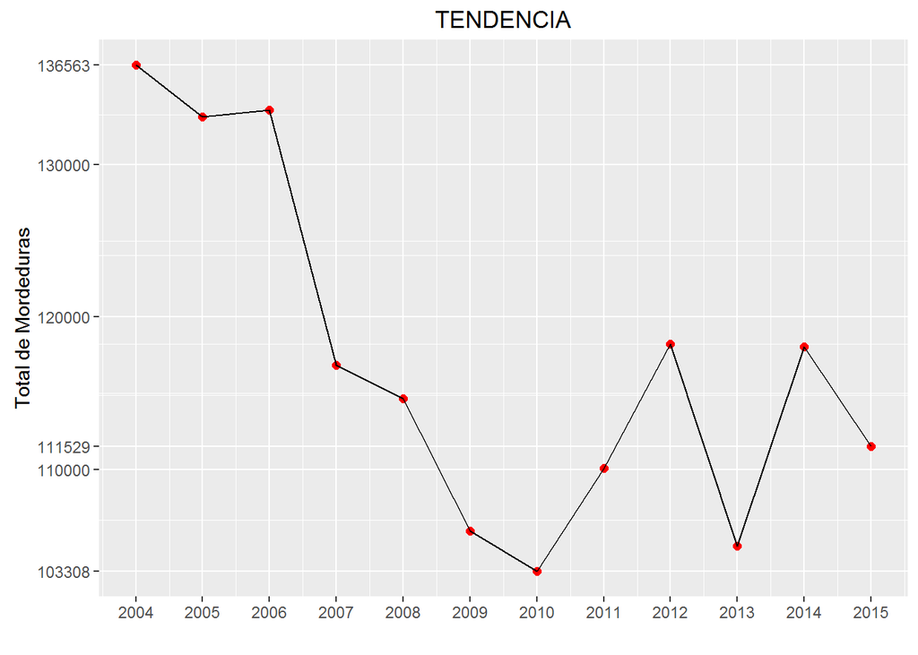

Se creó una gráfica que presentara el total de mordeduras en cada año. Por espacio y limpieza se decidió dejar solo algunos intervalos entre los que destacan el número máximo de mordeduras y el número mínimo de mordeduras.

### 6.3 Multigráficas a través de los años

#### 6.3.1 El cambio de las Mordeduras en Cada Estado

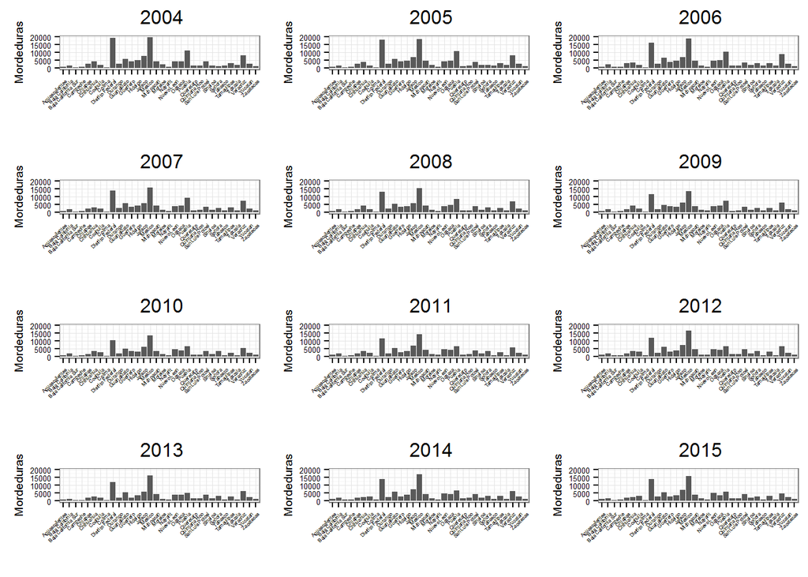

#### 6.3.2 El Cambio de las Mordeduras en Cada Fuente de Notificación

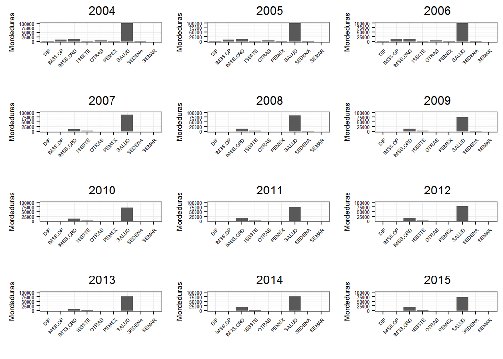

#### 6.3.3 El Cambio de las Mordeduras en Mes de Ocurrencia

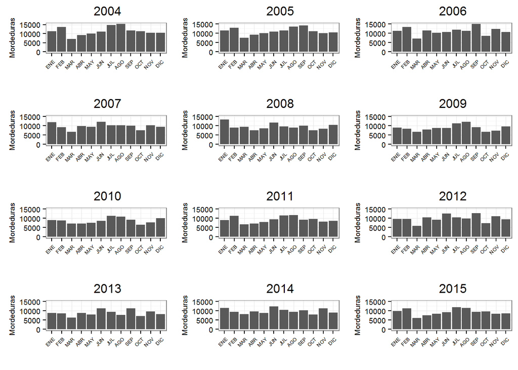

Esta gráfica permite hacer una comparación con la gráfica de tendencia y ver que en efecto, a través de los años va bajando la incidencia en mordeduras de perro. En general las gráficas no parecen variar mucho un mes con respecto al otro, y esta característica se mantiene a lo largo de los doce año que se analizaron. Dicho resultado no es difícil de digerir, si consideramos que los perros muerden por igual en todos los meses del año, uno pudiese esperar ciertos cambios en determinados meses del año por los ciclos de reproducción, sin embargo no hay evidencia de que esto afecte considerablemente.

#### 6.3.4 El Cambio de las Mordeduras en Grupo de Edad

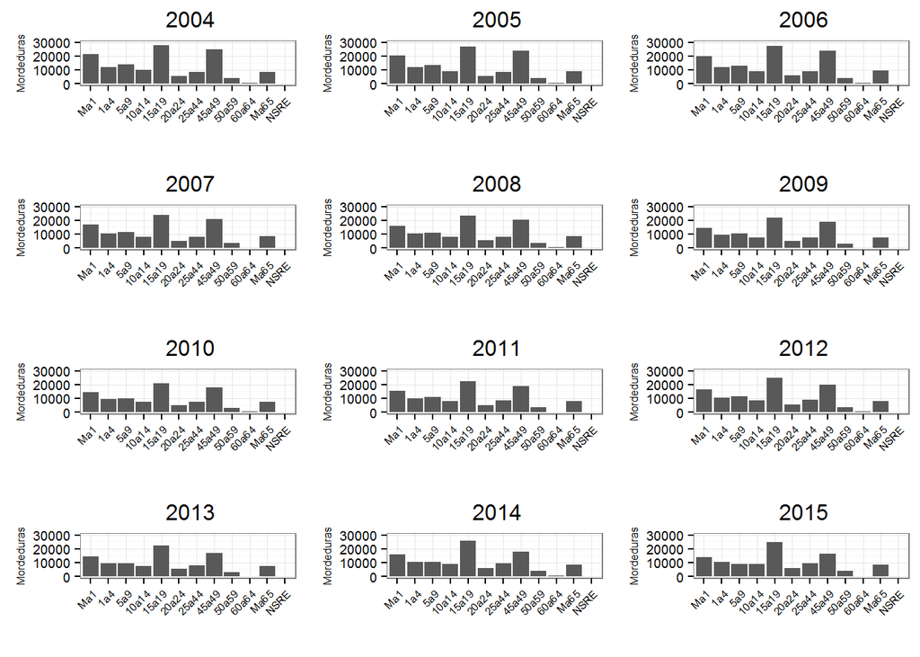

### 6.4 Boxplots

Para cada Boxplot el promedio está representada por un rombo rojo. Un boxplot o diagrama de caja proporciona una visión general de la simetría de la distribución de los datos. Este dipo de diagrama es útil para ver la presencia de valores atípicos, la dispersión de los puntos con la mediana, los percentiles 25 y 75, y los valores máximos y mínimos. Note que el 50% de la población está en los límites de la “caja”.

#### 6.4.1 Boxplot del Total de Mordeduras a Través de los Años de Cada Estado

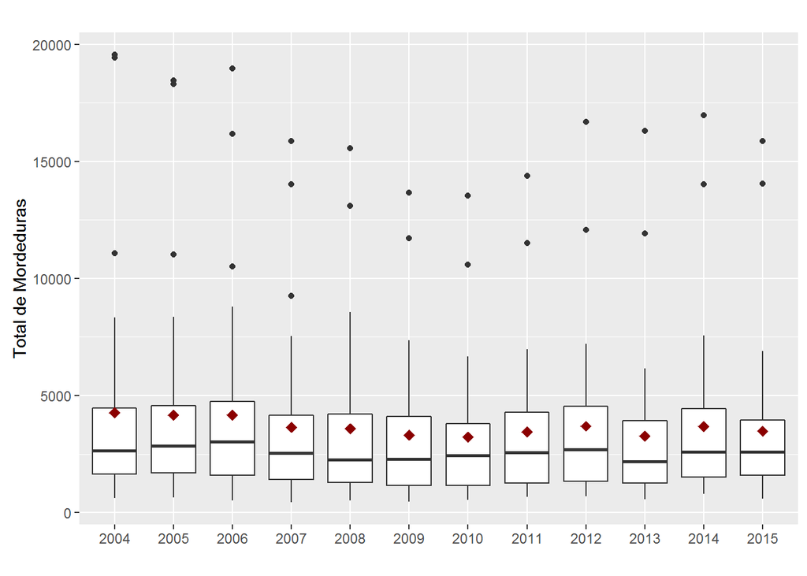

En este boxplot se representa el total de mordeduras que hubo a través de los años para cada estado. Por medio de esto se permite deducir que en todos los años el promedio de mordeduras estaba por arriba del valor en el cual se acumulaba el 50% de la distribución (i.e mediana). Esto es evidencia de que la distribución de la incidencia en mordeduras se encuentra sesgada a la derecha en todos los años, es decir la distribución está muy cargada a la derecha (e.g si pensamos en una distribución normal ésta sería más “gorda” del lado derecho). Con respecto a los valores fuera de los límites del diagrama, destaca el “Distrito Federal” y el Estado de México, en este caso “México”. Ambos registran el mayor número de mordedruras de todos los estados. La media generalmente se encuentra alrededor de 5000 y 2500, aproximadamente muerden esta cantidad de perros a personas en los estados. Podríamos formular hipótesis al respecto, probablemente exista una relación directa entre el número de personas que habitan una región y el número de perros, recordemos que estos son animáles domésticos.

##### 6.4.1.2 Boxplot del Total de Mordeduras a Través de los Años de Cada Estado para Hombres y Mujeres

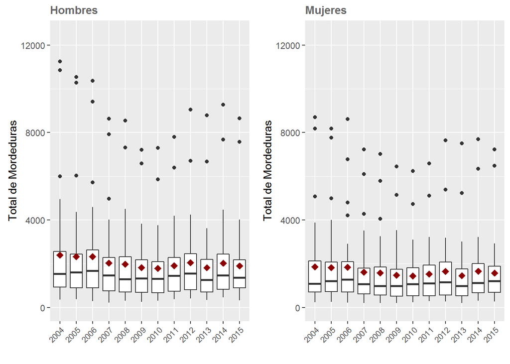

Este diagrama hace la separación de hombres y mujeres.Nuevamente podemos apreciar que el promedio tiende a estar hacia la parte de arriba de la “caja”. Un punto a resaltar, es que en cuanto a Hombres y Mujeres se puede llegar a la conclusión que en general muerden más a hombres que a mujeres en todos los Estados.Comparando los datos de hombres con los datos de mujeres, los promedios se encuentran por el mismo intervalo y no es demaisada la dispersión de estos.

#### 6.4.2 Boxplot del Total de Mordeduras a Través de los Años de Fuente de Notificación

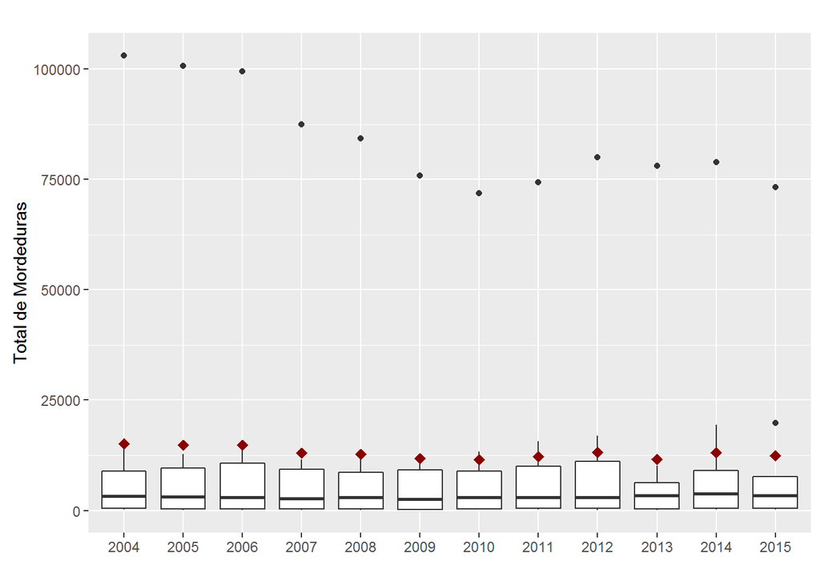

En este caso vemos que el promedio de Fuente de Notificación se localiza fuera de la “caja”. Esto ocurre porque en Fuente de Notificación existen varios “Sin registros” por parte de las instituciones y como la institución “SALUD” contiene la mayoría de los casos desplaza al promedio por arriba de la mitad de la “caja”, convirtiéndose “SALUD” en un valor extremadamente raro.

##### 6.4.2.1 Boxplot del Total de Mordeduras a Través de los Años de Fuente de Notificación para Hombres y Mujeres

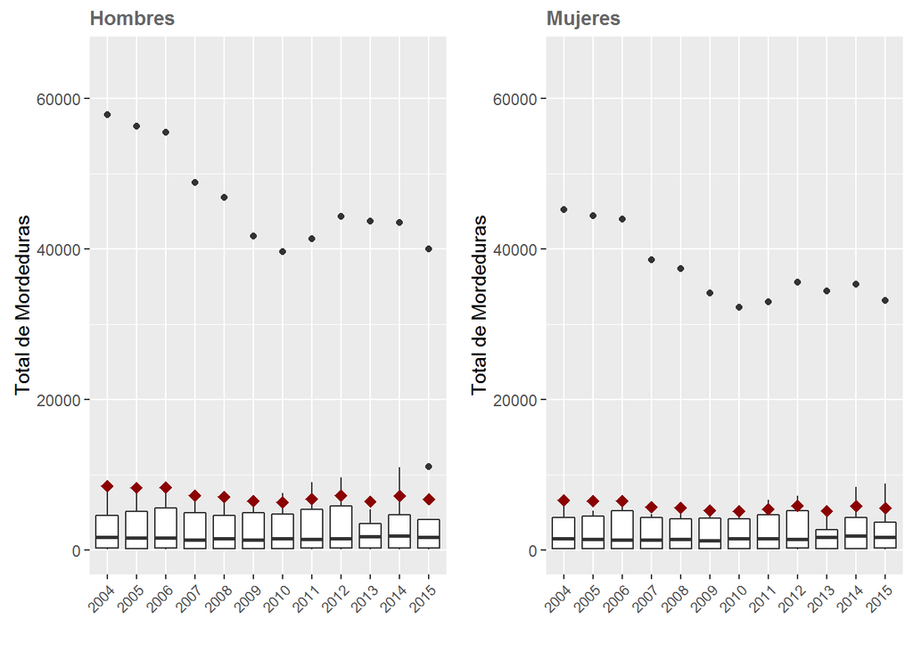

Consideramos los boxplots de hombres y mujeres para fuente de notificación para entender cómo se estaban registrando las mordeduras para ambos géneros. Pudimos notar que las instituciones registran más hombres que mujeres con mordeduras de perro. Aun así, al igual que por Estados, el promedio y el valor que acumula el 50% de la distribución no tienen un gran cambio en hombre mujer.

#### 6.4.3 Boxplot del Total de Mordeduras a Través de los Años de Fuente de Mes de Ocurrencia

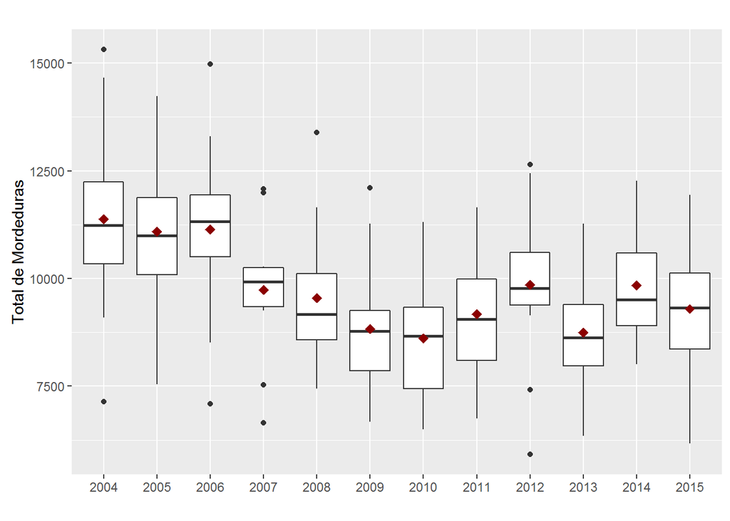

En Mes de Ocurrencia se presentan datos más dispersados que en los pasados diagramas. Hay sesgos a las derecha como a la izquierda. Esto es que los promedios a través de los años varían en dónde se localizan, hay tanto por arriba de la mitad de la “caja”, como por debajo de ella. Incluso notamos que en varios años, por ejemplo 2015, que el promedio se acerca a la mitad del diagrama (i.e simetría). En algunos años no existen valores fuera de los límites del diagrama. Si se compara con la gráfica de Tendencia se concluye que es razonable que la media vaya bajando a través de los años ya que previamente se encontró evidencia que la cantidad mordeduras disminuyó con en el transcurso del tiempo.

##### 6.4.3.1 Boxplot del Total de Mordeduras a Través de los Años de Mes de Ocurrencia para Hombres y Mujeres

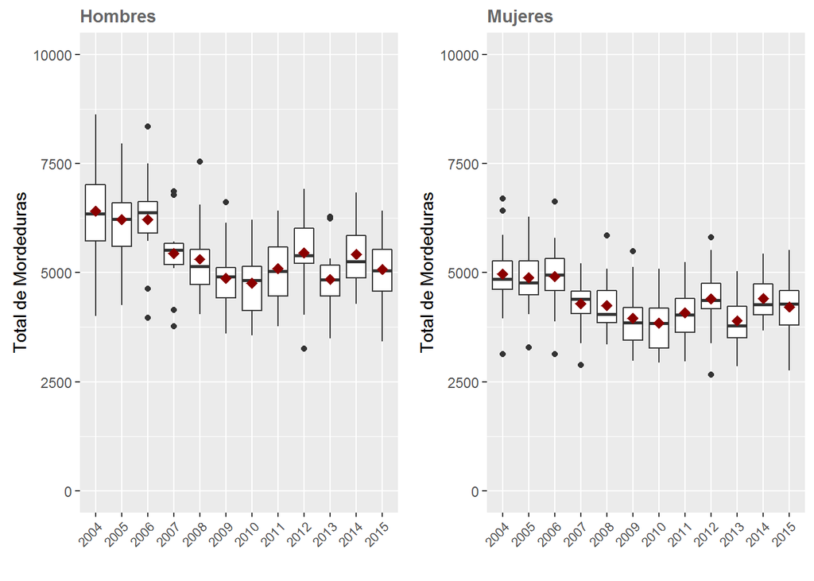

#### 6.4.4 Boxplot del Total de Mordeduras a Través de los Años de Grupo de Edad

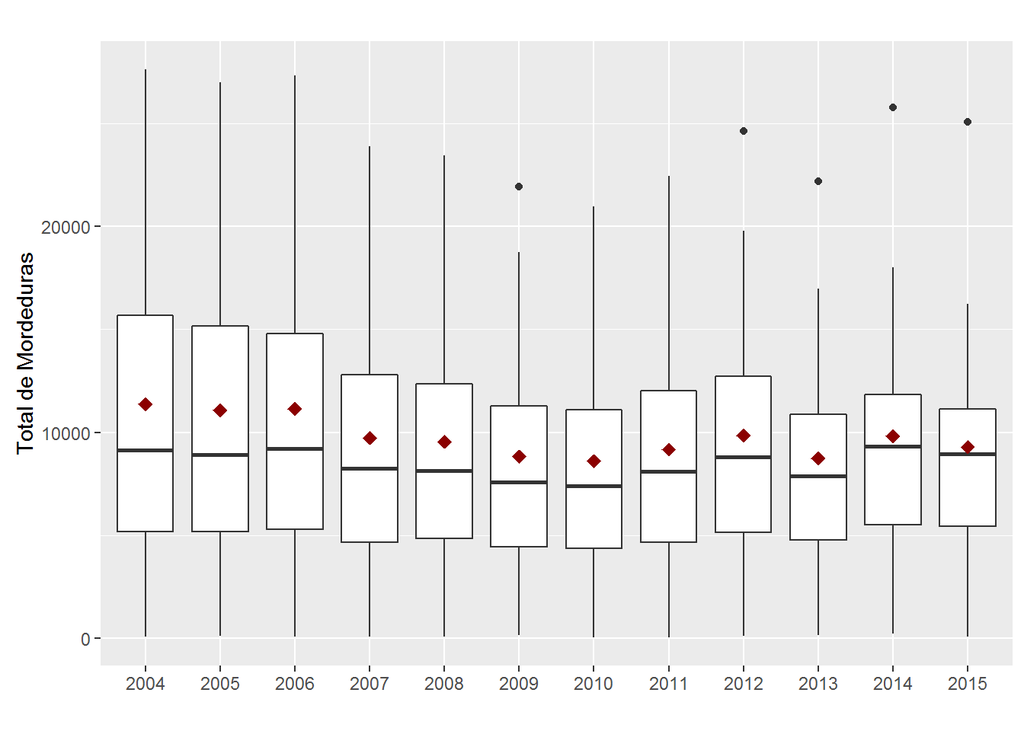

En el boxplot de Grupo de Edad apreciamos un sesgo a la derecha en todos los años, pero se puede ver también que el sesgo ha estado disminuyendo através de los años, esto hace la media más cercana a la mediana. Con lo anterior se puede argumentar que ha habido mayor similitud en las mordeduras de grupos de edad a través de los años. Uno de los problemas que siempre registrará el gurpo de edad es que existe un intervalo demasiado grande que abarca a más persona que en otro.

##### 6.4.4.1 Boxplot del Total de Mordeduras a Través de los Años de Grupo de Edad para Hombres y Mujeres

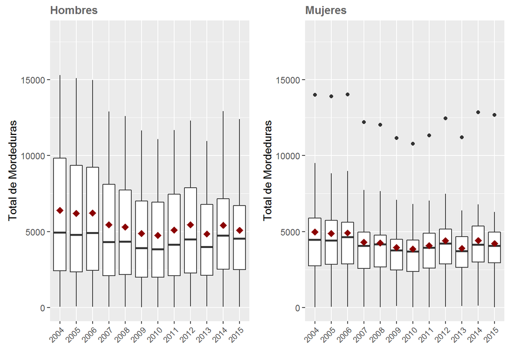

En el boxplot de Hombres notamos un sesgo a la derecha mucho mayor que en el de las mujeres. En el de las mujeres apreciamos un mayor acercamiento a la simetría que en el caso de los hombres.

## 7. Conclusiones

Después de observar, analizar y graficar los datos obtenidos, se pudo concluir: Primero, los datos de cualquiera de las fuentes (Fuente de Notificación, Mes de Ocurrencia o Grupo de Edad) presentan una gran similitud a través de los años, podrán variar y disminuir las mordeduras perro en cada una de las variables originales, siempre oscilan en el mismo intervalo. Esto nos obliga a dudar de la veracidad de los datos, nos hace preguntarnos si en verdad se están capturando los datos de manera eficiente y real. En caso de que estemos equivocados tenemos que concluir que las Mordeduras de Perro presentan un patrón muy común. Se pueden utilizar métodos numéricos para crear aproximaciones a los patrones y hacer buenas estimaciones de los próximos años.

Otra de nuestras conclusiones nace de la captura de los datos. En fuente de Notificación, prácticamente solo hay una institución que está registrando las mordeduras de perro, también creemos que “OTRAS” puede llegar a resultar muy ambiguo y con motivos a dudar si en “OTRAS” se incluyen a todas las instituciones públicas como tanto privadas. En Grupo de Edad, se deben cambiar los intervalos de edad porque al momento de hacer cualquier análisis estadístico se alteraran las conclusiones si se tiene un intervalo de 19 años.

Creemos que México debe ser educado en cuanto a la captura de información, México no se está actualizando en las capturas de información y esto está provocando análisis dudosos y poco nutritivos. Si los análisis se están haciendo con datos falsos o con datos faltantes se están haciendo análisis falsos y análisis incompletos. Cada país toma decisiones con base a análisis estadísticos, porque estos se encargan de presentar pronósticos y aproximaciones de la realidad, y con esto dichas decisiones más acertadas a lo demandado por la realidad. Si México está capturando erróneamente sus datos está produciendo datos falsos y esto implicaría malas decisiones, y un mal empleo de los recursos.

Creemos que es tiempo de revisar y cuestionar los métodos utilizados para capturar información, ya que los estadísticos tiene como obligación presentar datos verídicos como los menciona Stephen Few y como lo establece “The Actuarial Standard of Practice” Se debe ser crítico con los datos y mucho más con nuestro trabajo como lo menciona Edward Tufte, por eso en este trabajo se trata de ser muy crítico y reflejar la realidad de los datos capturados.